# Using the new NAU Tagger

Author of this tutorial: Larissa Goulart  
Operating system: Windows  
Tested on 08/28/2020

### **Before we start**

The goal of this tutorial is to teach you how to tag your corpus with the new NAU tagger. You will need to download:

**1. CLAWS**

- Download [CLAWS](http://ucrel.lancs.ac.uk/claws/) and [AntCLAWSGUI](https://www.laurenceanthony.net/software/antclawsgui//). Don’t forget to unzip the files and to save both programs in the same folder.  
  You can download both together [here](https://www.dropbox.com/sh/49fdewbkfb2g8sh/AAAbR1rKcVc_Z_7hQNAfTdLJa?dl=0)

**2. New NAU Tagger**

- Download the files of the new [NAU Tagger](https://www.dropbox.com/sh/h6dom7ap2wqsvr5/AAB_7SlEEtb047Fc8HD2bsFNa?dl=)

**3. Python**

- Download [Python](https://www.python.org/downloads/)

**4. Practice files**

- If you need you can download a folder with some txt files to practice [here](https://www.dropbox.com/sh/j0uugo2n1zko101/AACfX8RSCX-_3nDQciQMooPZa?dl=0).

### **Overview**

Here is a general overview of this tutorial:

1.Preparing the files  
2.Running CLAWS7  
3.Running the new NAU Tagger

### **1.Preparing the files**

If your files are not in .txt format, or encoded in utf-8, you won’t be able to run the new NAU tagger. Here is a way to convert, encode and standardize your files.  
If your files are ready, skip to step 2.

#### **1.1. [Corpus Text Processor](https://github.com/writecrow/ciabatta/wiki/1.-Tools:-Corpus-Text-Processor#installation)**

We will use CROW’s Corpus Text Processor to prepare the files. I recommend that you create three folders in your computer that mirror the menus in the Corpus Text Processor: 01_converted, 02_encoded, and 03_standardized before running the tool. It should look like this.

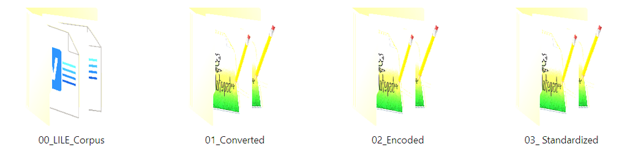

And this is what you will see when you open the Corpus Text Processor

[figure not shown]

To convert the files, we will follow the order of the menus in the Corpus Text Processor. You can also watch the [video demonstration](https://drive.google.com/file/d/1xMiHrJzF1L5kjS3wVGVIF8OmlQQ5iI4q/view) on how to run it.

### **2.Running CLAWS7**

#### **2.1. Save all the files in the same folder**

- Unzip the CLAWS7 files
- Save AntCLAWSGUI in the CLAWS7 folder

It should look like this on your computer:

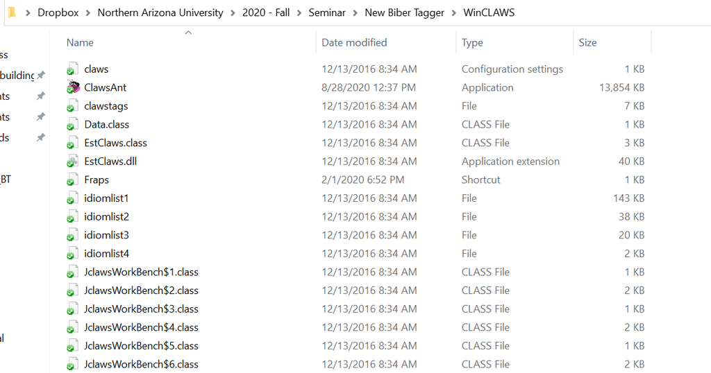

#### **2.2. Annotating your corpus with CLAWS7**

- Open the AntCLAWSGUI interface

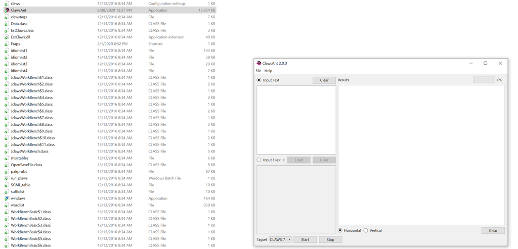

- Open the files or directory you want to tag

`File> Open File(s)/Open Dir..`

[figure not shown]

- Select the second Input Files box

[figure not shown]

- Keep the **Horizontal** setting checked
- Press **Start**

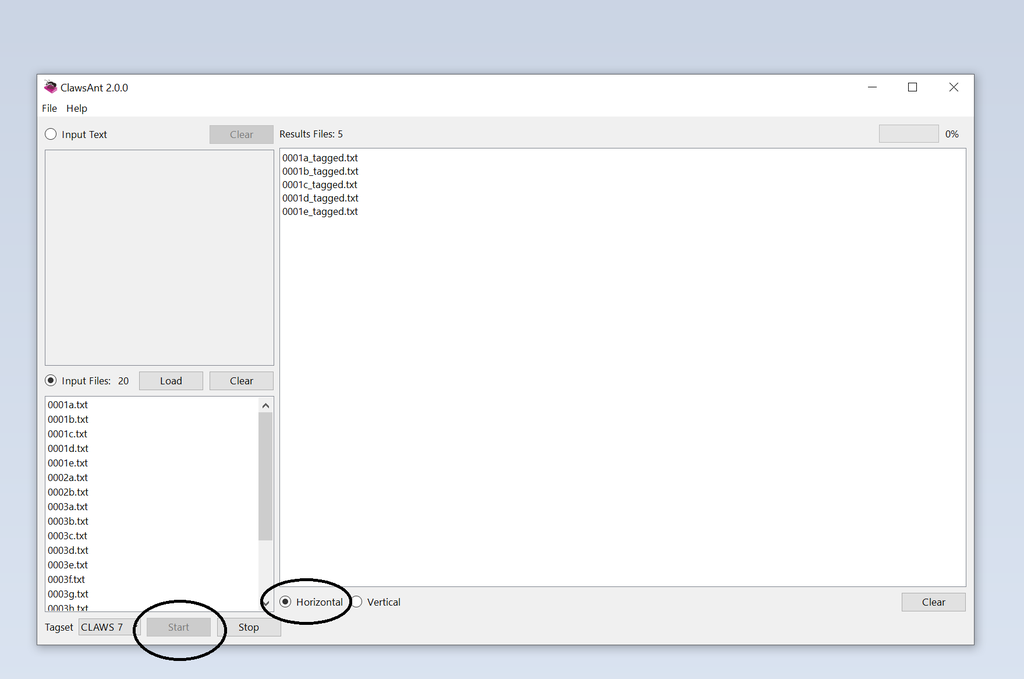

- Copy the tagged files to a new folder
- It is important to have the NAU Tagger and your files in the same directory.

Here is how it looks like on my computer:

[figure not shown]

### **3.Running the new NAU Tagger**

#### **3.1. Create a folder where you will save the tagged files**

Remember to create this file in the same directory.

Here is how it looks like on my computer:

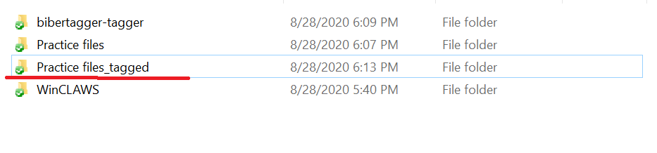

#### **3.2. Navigating to the *bibertagger-tagger* folder**

- Open *Power Shell ISE*

[figure not shown]

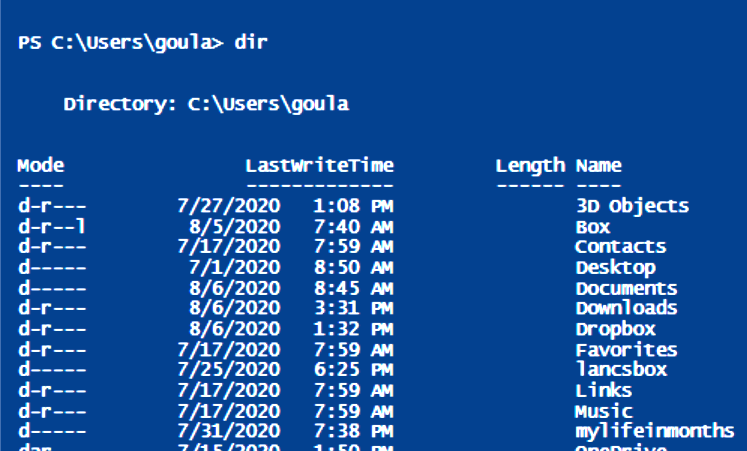

- Use `cd` to navigate to the directory where you saved the *bibertagger-tagger* folder

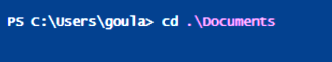

If you run into an error, check that you are doing `cd` + space + the name of the folder. You can also use tab to autocomplete the name of the directory.

Once you find the folder you are looking for, press Enter

This is how it should look like:

[figure not shown]

I saved the *bibertagger-tagger* folder in my `documents`. So, in my computer, this is the code I need to type:

`cd Documents\new_tagger\bibertagger-tagger`

#### **3.3. Running the new NAU Tagger in a folder**

To annotate a whole directory, this is the code you will use:

`python claws2biber.py` `path to the input directory` `path to the output directory`

This is how the code will look like on my computer:

`python .\claws2biber.py '..\Practice files' '..\Practice files_tagged'`

Where `..\` means that I am going back one folder.

This is how it looks like on my computer:

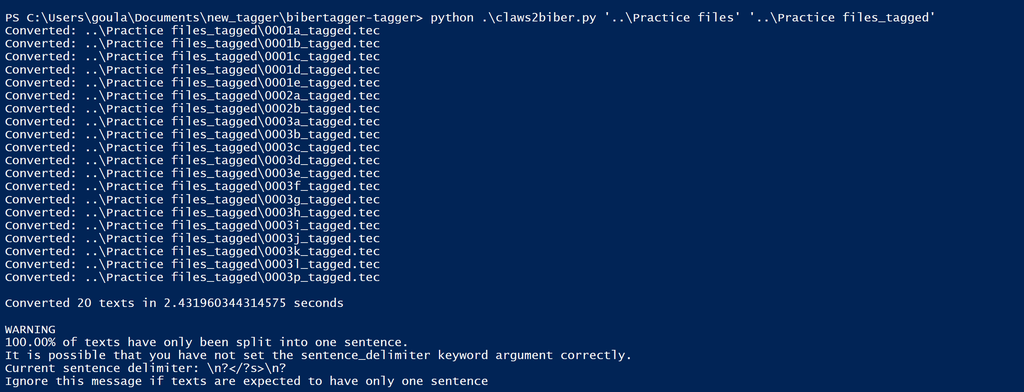

The files will be saved with a `tec` extension, to change that you can add the flag `--ext txt` to the code.

Then, the code will look like this:

`python .\claws2biber.py '..\Practice files' '..\Practice files_tagged' --ext txt`

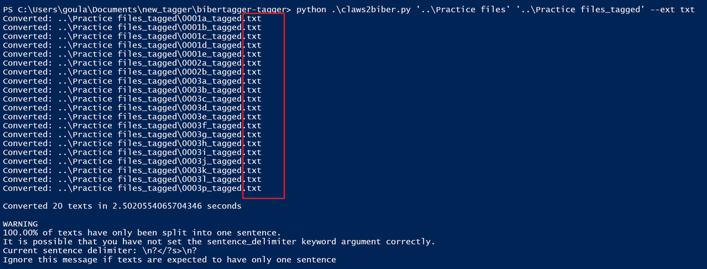